[output not shown]

# Mesh convergence study (GCI)

### TIFON aerofoil — CODA solver — FotR `CODA_SINGLE` format

## Purpose

Quantify the **numerical uncertainty due to spatial discretisation** at three flight conditions of the TIFON aerofoil. Each condition has been solved on the same geometry over a family of eleven meshes of increasing refinement; the question is how much of the solution still depends on the mesh rather than on the physics.

The study is processed with FotR's `CODA_SINGLE` format, written for databases in which **every simulation carries its own mesh** — unlike the classic `CODA` format, which assumes one mesh shared by all cases.

## Conventions used here

Richardson extrapolation and the GCI need no introduction; what follows fixes the notation and, more importantly, states the conventions this study adopts, since several of them are choices rather than standards.

### Mesh family: the refinement factor

The meshes are generated in gmsh from a single dimensionless parameter $f$, which sets both the characteristic cell sizes and the aerofoil discretisation:

$$ \ell_{\mathrm{ff}} = 5\times10^{-2}\,f \quad\text{(farfield)}, \qquad \ell_{a} = 3\times10^{-5}\,f \quad\text{(aerofoil)} $$

$$ N_{\text{aerofoil}} = \left\lfloor \frac{6500}{f^{\,0.8}} \right\rfloor $$

Cell sizes are **linear in $f$**, so

$$ h \propto f $$

and every ratio $h_i/h_j$ equals $f_i/f_j$ exactly. That is what licenses using the factor directly as the representative size in the GCI, with no need to measure areas or volumes: the proportionality constant cancels in the ratios. §2 checks that the meshes actually generated obey this law.

### Richardson extrapolation

For a consistent scheme with the solution inside the **asymptotic range**, a quantity of interest $\phi$ computed on a mesh of representative size $h$ behaves as

$$ \phi(h) = \phi_{h\to 0} + C\,h^{\,p} + \mathcal{O}(h^{\,p+1}) $$

with $\phi_{h\to 0}$ the (unreachable) discretisation-free value, $C$ a constant and $p$ the **observed order of convergence**. For three meshes $h_1 < h_2 < h_3$ with values $\phi_1, \phi_2, \phi_3$:

$$ r_{21} = \frac{h_2}{h_1}, \qquad r_{32} = \frac{h_3}{h_2}, \qquad \varepsilon_{21} = \phi_2 - \phi_1, \qquad \varepsilon_{32} = \phi_3 - \phi_2 $$

and the observed order follows from the fixed-point iteration

$$ p = \frac{1}{\ln r_{21}} \left| \ln\left|\frac{\varepsilon_{32}}{\varepsilon_{21}}\right| + q(p) \right|, \qquad q(p) = \ln\!\left(\frac{r_{21}^{\,p}-s}{r_{32}^{\,p}-s}\right), \qquad s = \mathrm{sign}\!\left(\frac{\varepsilon_{32}}{\varepsilon_{21}}\right) $$

Note the ratios are **not** assumed equal: $q(p)$ is retained throughout, since most of the triplets examined here have $r_{21} \neq r_{32}$. With $p$ known,

$$ \phi_{\mathrm{ext}}^{21} = \frac{r_{21}^{\,p}\,\phi_1 - \phi_2}{r_{21}^{\,p} - 1} $$

### Grid Convergence Index

Roache's GCI turns the difference between meshes into an **uncertainty band**, with a safety factor $F_s = 1.25$ (the three-mesh value):

$$ \mathrm{GCI}_{21} = \frac{F_s\,\left|e_a^{21}\right|}{r_{21}^{\,p} - 1}, \qquad e_a^{21} = \frac{\phi_1 - \phi_2}{\phi_1} $$

read as: *the fine-mesh value lies within $\pm\,\mathrm{GCI}_{21}$ of the discretisation-free value, at roughly 95 % confidence.*

The companion indicator is the **asymptotic ratio**

$$ \frac{\mathrm{GCI}_{32}}{r_{21}^{\,p}\,\mathrm{GCI}_{21}} \approx 1 $$

which holds only if the triplet genuinely sits in the asymptotic range. It carries a lot of weight later on: §4 ranks triplets largely by how close this quantity is to unity.

### Applicability

The procedure is **not always applicable**, and forcing it produces numbers with no meaning:

[output not shown]

All of them are implemented in `CODASingleStats.richardson`, which returns `NaN` with `converged = False` rather than a number that merely looks authoritative.

# 1. Databases

Each `aoa_*_m_*` root is a self-contained FRODO database: one fixed flight condition solved over the whole mesh family.

Database overview

| database | aoa_0.022_m_1.071 | aoa_0.022_m_1.386 | aoa_3.303_m_0.541 |
| --- | --- | --- | --- |
| format | CODA_SINGLE | CODA_SINGLE | CODA_SINGLE |
| equations | rans | rans | rans |
| design variables | aoa, mach, mesh | aoa, mach, mesh | aoa, mach, mesh |
| cases | 11 | 11 | 11 |
| stages per case | 2 | 2 | 2 |
| folder pattern | f{mesh:g} | f{mesh:g} | f{mesh:g} |
| reader | CODASingleReader | CODASingleReader | CODASingleReader |
| sets | CODASingleSets | CODASingleSets | CODASingleSets |
| stats | CODASingleStats | CODASingleStats | CODASingleStats |
| residuals | CODAResiduals | CODAResiduals | CODAResiduals |

## 1.1 Flight conditions and mesh family

The design variables are `aoa`, `mach` and `mesh` (the factor $f$). Within each database **only `mesh` varies**: the other two are constant and define the flight condition.

Flight conditions

| database | AoA [deg] | Mach | meshes | f factors |
| --- | --- | --- | --- | --- |
| aoa_0.022_m_1.071 | 0.022154 | 1.0715 | 11 | 0.75, 0.8, 0.85, 0.9, 0.95, 1, 1.5, 2, 3, 6, 10 |
| aoa_0.022_m_1.386 | 0.022154 | 1.3858 | 11 | 0.75, 0.8, 0.85, 0.9, 0.95, 1, 1.5, 2, 3, 6, 10 |
| aoa_3.303_m_0.541 | 3.3034 | 0.54138 | 11 | 0.75, 0.8, 0.85, 0.9, 0.95, 1, 1.5, 2, 3, 6, 10 |

## 1.2 Layout on disk

A case is a subdirectory of `outputs/`, carrying its own mesh and its per-stage output files. Rows are ordered by **increasing $f$** — finest to coarsest mesh — rather than by folder name.

aoa_0.022_m_1.071

| case | f | lc aerofoil [m] | mesh file | stages | files |
| --- | --- | --- | --- | --- | --- |
| f0.75 | 0.75 | 2.25e-05 | mesh_f22_v8_f0.75.msh | 0, 1 | 20 |
| f0.8 | 0.8 | 2.4e-05 | mesh_f22_v8_f0.8.msh | 0, 1 | 20 |
| f0.85 | 0.85 | 2.55e-05 | mesh_f22_v8_f0.85.msh | 0, 1 | 20 |
| f0.9 | 0.9 | 2.7e-05 | mesh_f22_v8_f0.9.msh | 0, 1 | 20 |
| f0.95 | 0.95 | 2.85e-05 | mesh_f22_v8_f0.95.msh | 0, 1 | 20 |
| f1 | 1 | 3e-05 | mesh_f22_v8_f1.0.msh | 0, 1 | 20 |
| f1.5 | 1.5 | 4.5e-05 | mesh_f22_v8_f1.5.msh | 0, 1 | 21 |
| f2 | 2 | 6e-05 | mesh_f22_v8_f2.0.msh | 0, 1 | 20 |
| f3 | 3 | 9e-05 | mesh_f22_v8_f3.0.msh | 0, 1 | 21 |
| f6 | 6 | 0.00018 | mesh_f22_v8_f6.0.msh | 0, 1 | 21 |
| f10 | 10 | 0.0003 | mesh_f22_v8_f10.0.msh | 0, 1 | 21 |

aoa_0.022_m_1.386

| case | f | lc aerofoil [m] | mesh file | stages | files |
| --- | --- | --- | --- | --- | --- |
| f0.75 | 0.75 | 2.25e-05 | mesh_f22_v8_f0.75.msh | 0, 1 | 20 |
| f0.8 | 0.8 | 2.4e-05 | mesh_f22_v8_f0.8.msh | 0, 1 | 20 |
| f0.85 | 0.85 | 2.55e-05 | mesh_f22_v8_f0.85.msh | 0, 1 | 20 |
| f0.9 | 0.9 | 2.7e-05 | mesh_f22_v8_f0.9.msh | 0, 1 | 20 |
| f0.95 | 0.95 | 2.85e-05 | mesh_f22_v8_f0.95.msh | 0, 1 | 20 |
| f1 | 1 | 3e-05 | mesh_f22_v8_f1.0.msh | 0, 1 | 20 |
| f1.5 | 1.5 | 4.5e-05 | mesh_f22_v8_f1.5.msh | 0, 1 | 20 |
| f2 | 2 | 6e-05 | mesh_f22_v8_f2.0.msh | 0, 1 | 20 |
| f3 | 3 | 9e-05 | mesh_f22_v8_f3.0.msh | 0, 1 | 21 |
| f6 | 6 | 0.00018 | mesh_f22_v8_f6.0.msh | 0, 1 | 21 |
| f10 | 10 | 0.0003 | mesh_f22_v8_f10.0.msh | 0, 1 | 20 |

aoa_3.303_m_0.541

| case | f | lc aerofoil [m] | mesh file | stages | files |
| --- | --- | --- | --- | --- | --- |
| f0.75 | 0.75 | 2.25e-05 | mesh_f22_v8_f0.75.msh | 0, 1 | 20 |
| f0.8 | 0.8 | 2.4e-05 | mesh_f22_v8_f0.8.msh | 0, 1 | 20 |
| f0.85 | 0.85 | 2.55e-05 | mesh_f22_v8_f0.85.msh | 0, 1 | 20 |
| f0.9 | 0.9 | 2.7e-05 | mesh_f22_v8_f0.9.msh | 0, 1 | 20 |
| f0.95 | 0.95 | 2.85e-05 | mesh_f22_v8_f0.95.msh | 0, 1 | 20 |
| f1 | 1 | 3e-05 | mesh_f22_v8_f1.0.msh | 0, 1 | 20 |
| f1.5 | 1.5 | 4.5e-05 | mesh_f22_v8_f1.5.msh | 0, 1 | 20 |
| f2 | 2 | 6e-05 | mesh_f22_v8_f2.0.msh | 0, 1 | 20 |
| f3 | 3 | 9e-05 | mesh_f22_v8_f3.0.msh | 0, 1 | 20 |
| f6 | 6 | 0.00018 | mesh_f22_v8_f6.0.msh | 0, 1 | 20 |
| f10 | 10 | 0.0003 | mesh_f22_v8_f10.0.msh | 0, 1 | 20 |

Layout of each database, ordered by mesh factor.

## 1.3 Solver convergence

Final residuals of each case against the mesh factor $f$. Colour identifies the equation; the marker, whether the case reached the convergence threshold. The labels along the top axis are the `case_idx` by which each case is addressed.

This plot is worth more than a formality here: §4 will show that **which simulations converged is what ends up constraining the whole study**.

aoa_0.022_m_1.071

aoa_0.022_m_1.386

aoa_3.303_m_0.541

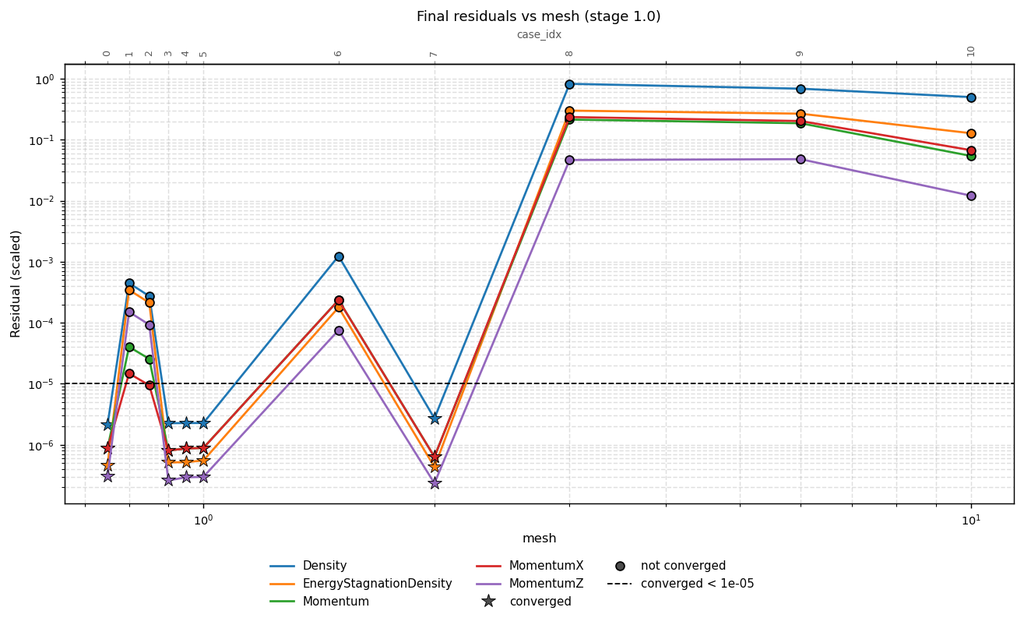

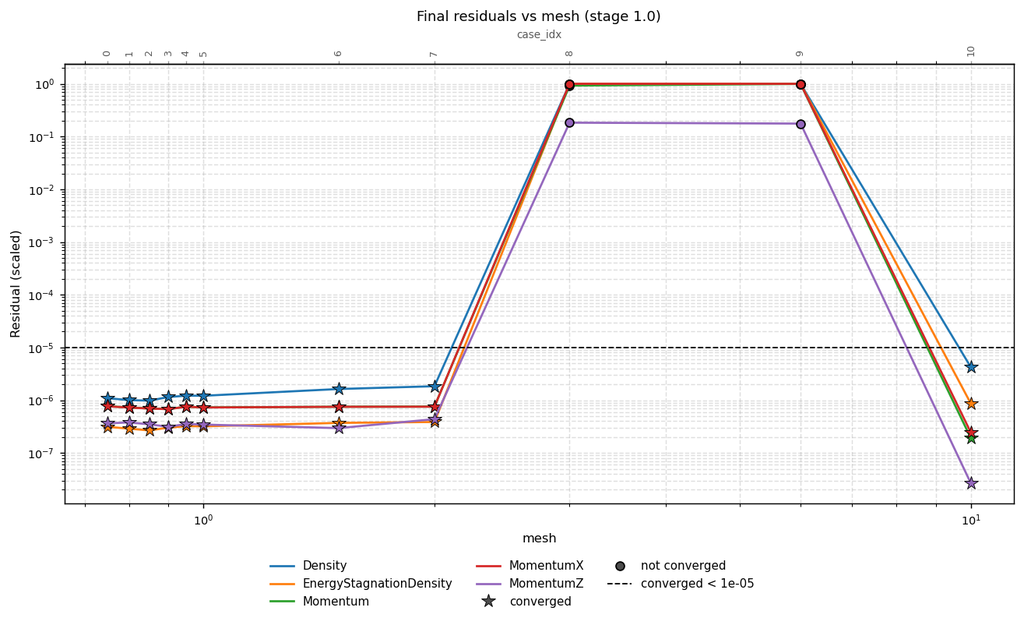

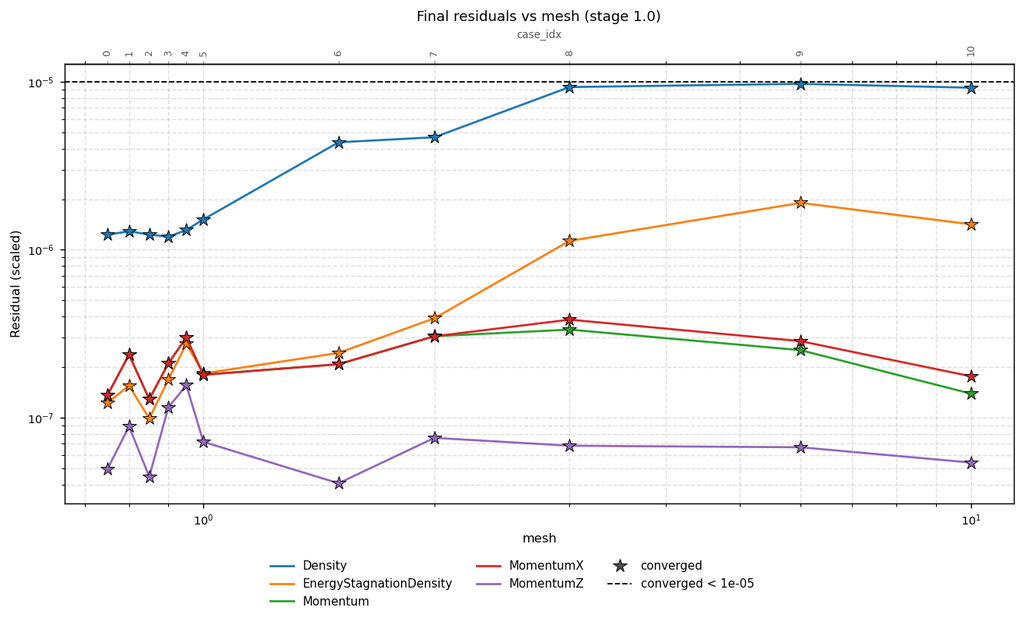

Scaled residuals at the end of the run. One mesh per point.

## 1.4 Wall integral monitors

Iteration history of the aerodynamic coefficients. Colour encodes refinement **sequentially** and the legend names each mesh, which is what helps when the case name is itself a physical quantity.

aoa_0.022_m_1.071

aoa_0.022_m_1.386

aoa_3.303_m_0.541

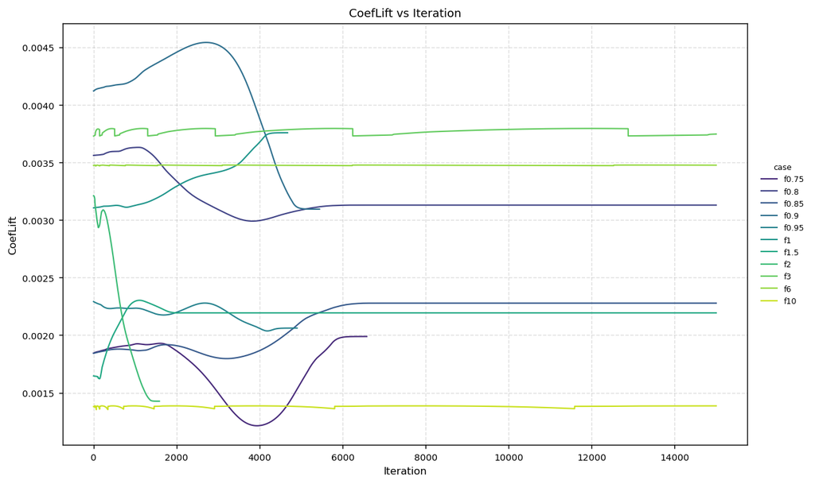

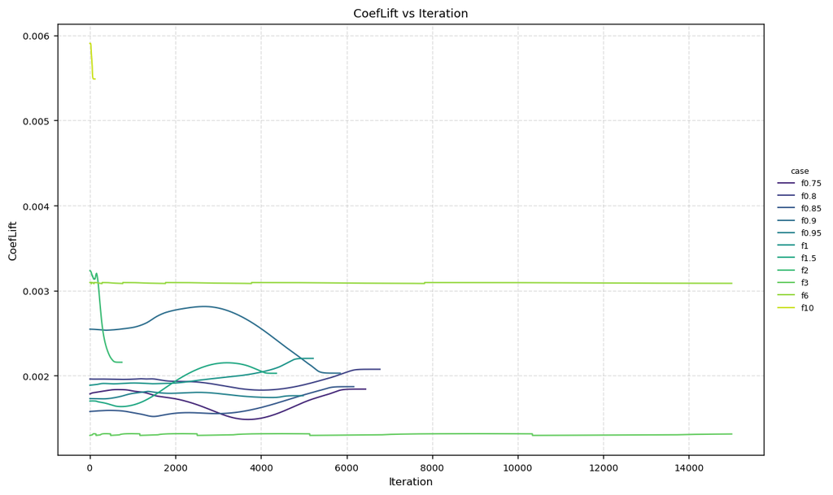

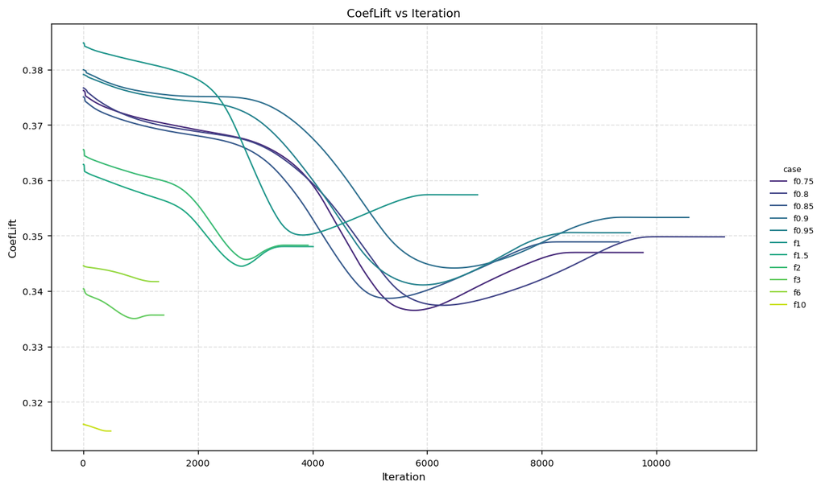

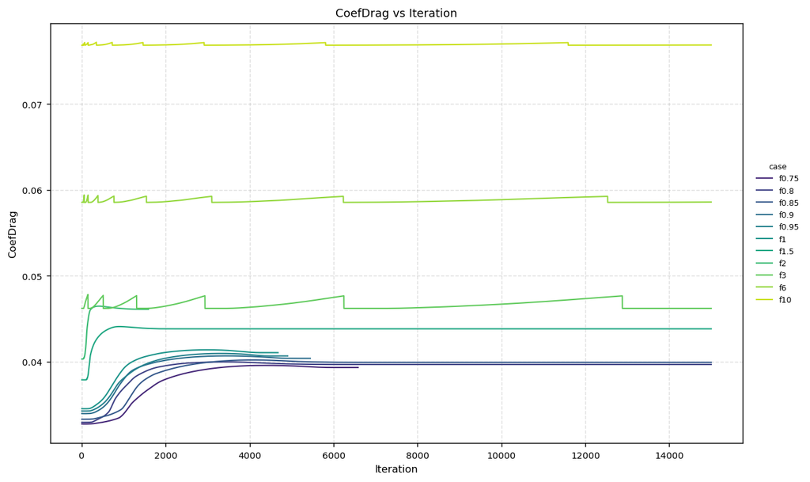

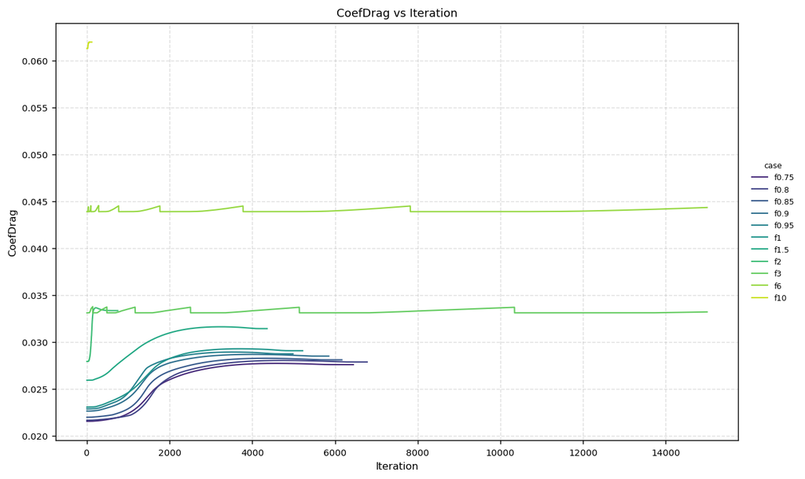

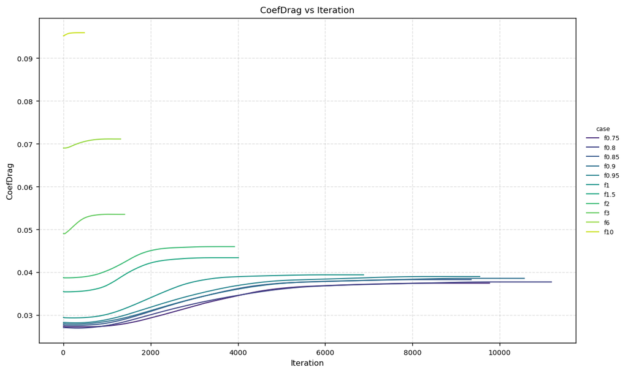

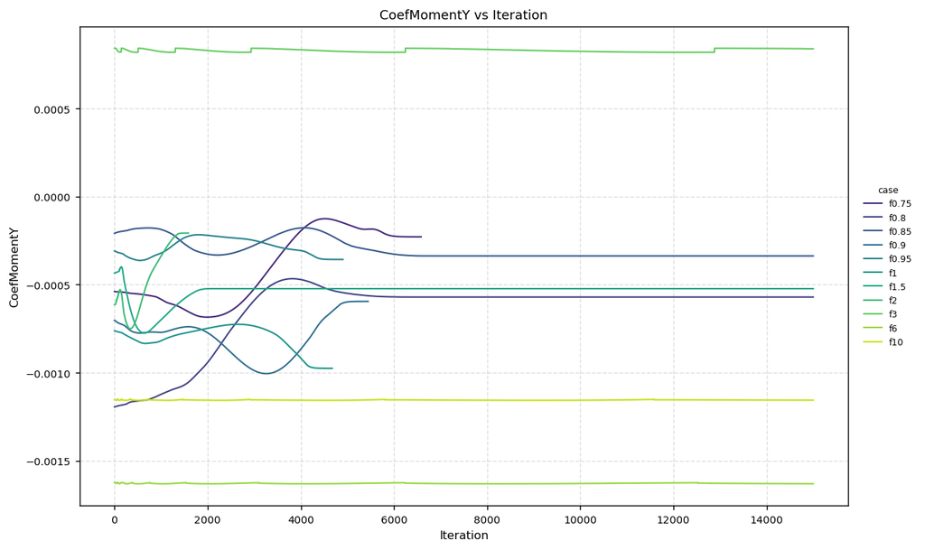

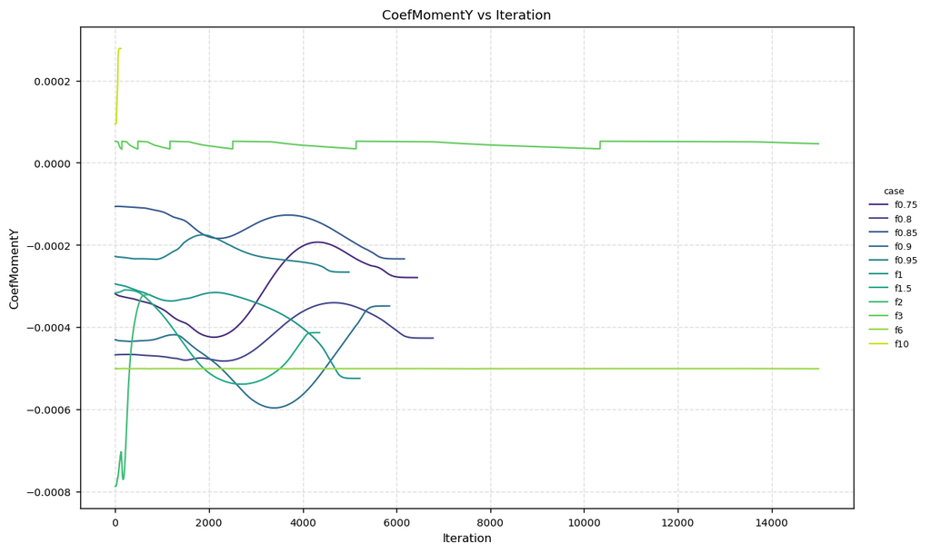

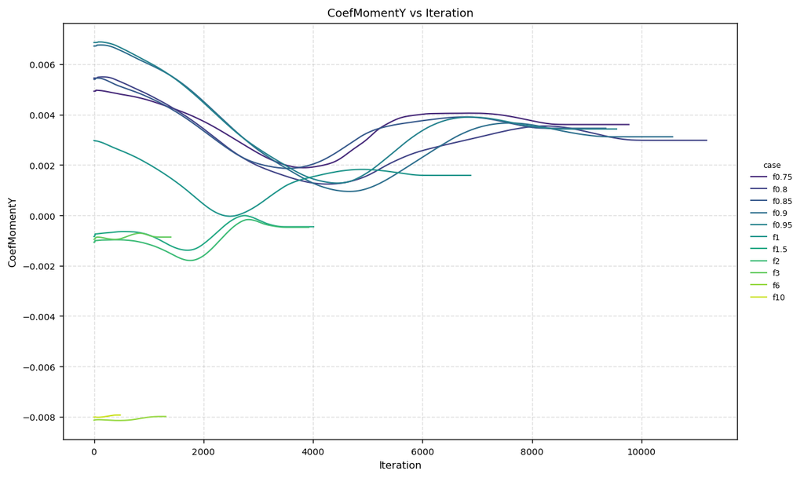

Iterative convergence of the wall integral coefficients (stage 1). One curve per mesh.

# 2. Mesh family and surface extraction

In `CODA_SINGLE` every case keeps **its own geometry**: `Coord`, `Conec` and the fields are lists aligned with the case order, not matrices sharing a point axis. That is the structural difference from the `CODA` format, and the reason meshes cannot be compared point by point — any comparison has to go through a reduction to a scalar first.

The three databases share exactly the same mesh family; only the flight condition solved on them differs.

Wall cells per mesh factor

| database | f | aoa_0.022_m_1.071 | aoa_0.022_m_1.386 | aoa_3.303_m_0.541 | theoretical ⌊6500/f^0.8⌋ | deviation |
| --- | --- | --- | --- | --- | --- | --- |
|  | 0.75 | 8181 | 8181 | 8181 | 8182 | -1 |
|  | 0.8 | 7769 | 7769 | 7769 | 7770 | -1 |
|  | 0.85 | 7401 | 7401 | 7401 | 7402 | -1 |
|  | 0.9 | 7070 | 7070 | 7070 | 7071 | -1 |
|  | 0.95 | 6499 | 6499 | 6499 | 6772 | -273 |
|  | 1 | 6499 | 6499 | 6499 | 6500 | -1 |
|  | 1.5 | 4698 | 4698 | 4698 | 4699 | -1 |
|  | 2 | 3732 | 3732 | 3732 | 3733 | -1 |
|  | 3 | 2698 | 2698 | 2698 | 2699 | -1 |
|  | 6 | 1549 | 1549 | 1549 | 1550 | -1 |
|  | 10 | 1029 | 1029 | 1029 | 1030 | -1 |

The three databases use the same mesh family, hence the three identical columns. The last column compares against the gmsh generation law.

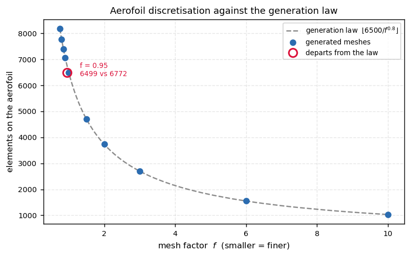

The meshes follow the generation law with one exception, circled in red. Linear axes; a single curve, since the three databases share the same family.

> **Anomaly in the mesh family.** One mesh does not follow the generation law: it discretises the aerofoil with the same element count as the next coarser mesh, even though **its volume mesh is refined** (the `.msh` file has the intermediate size it should, and the solution it produces differs).

> The consequence is that for that mesh **$f$ no longer describes its wall resolution**. The study attributes to it a refinement step of $r \approx 1.05$ that did not happen on the surface, and that fictitious ratio goes straight into the $r^{\,p}-1$ denominator of Richardson. The effect is severe for wall quantities (§3 and §6) and milder for the integral coefficients (§4), which do see the refined volume.

> It is excluded from every convergence computation that follows, and regenerating it would recover a refinement level currently lost.

# 3. Field statistics per mesh

The pressure coefficient $C_p$ is reduced to one scalar per mesh. That reduction is the only thing comparable across meshes that share no points, and it is the input to the field-based GCI of §6.

aoa_0.022_m_1.071

| case | f | cells | mean | RMS | min | max | std |
| --- | --- | --- | --- | --- | --- | --- | --- |
| f0.75 | 0.75 | 8181 | -0.02164 | 0.2044 | -0.3051 | 1.797 | 0.2033 |
| f0.8 | 0.8 | 7769 | -0.0217 | 0.2048 | -0.2924 | 2.217 | 0.2037 |
| f0.85 | 0.85 | 7401 | -0.02118 | 0.2044 | -0.295 | 2 | 0.2033 |
| f0.9 | 0.9 | 7070 | -0.02086 | 0.2044 | -0.275 | 1.322 | 0.2033 |
| f0.95 | 0.95 | 6499 | -0.02128 | 0.2043 | -0.3146 | 1.292 | 0.2032 |
| f1 | 1 | 6499 | -0.02144 | 0.2046 | -0.3314 | 1.299 | 0.2034 |
| f1.5 | 1.5 | 4698 | -0.01989 | 0.2073 | -0.3347 | 2.291 | 0.2063 |
| f2 | 2 | 3732 | -0.01986 | 0.209 | -0.3759 | 2.473 | 0.2081 |
| f3 | 3 | 2698 | -0.02462 | 0.2087 | -0.2918 | 1.276 | 0.2073 |
| f6 | 6 | 1549 | -0.02006 | 0.2113 | -0.3935 | 1.171 | 0.2103 |
| f10 | 10 | 1029 | -0.01514 | 0.218 | -0.3153 | 1.872 | 0.2175 |

aoa_0.022_m_1.386

| case | f | cells | mean | RMS | min | max | std |
| --- | --- | --- | --- | --- | --- | --- | --- |
| f0.75 | 0.75 | 8181 | 0.02874 | 0.1182 | -0.1868 | 1.78 | 0.1147 |
| f0.8 | 0.8 | 7769 | 0.02903 | 0.1192 | -0.1762 | 2.208 | 0.1156 |
| f0.85 | 0.85 | 7401 | 0.02965 | 0.1187 | -0.1783 | 1.948 | 0.115 |
| f0.9 | 0.9 | 7070 | 0.02997 | 0.1187 | -0.1412 | 1.27 | 0.1148 |
| f0.95 | 0.95 | 6499 | 0.03034 | 0.1188 | -0.1937 | 1.244 | 0.1148 |
| f1 | 1 | 6499 | 0.03026 | 0.1192 | -0.2107 | 1.19 | 0.1153 |
| f1.5 | 1.5 | 4698 | 0.03332 | 0.1245 | -0.2044 | 2.371 | 0.12 |
| f2 | 2 | 3732 | 0.03501 | 0.1282 | -0.2399 | 2.529 | 0.1233 |
| f3 | 3 | 2698 | 0.03297 | 0.1261 | -0.1817 | 1.239 | 0.1217 |
| f6 | 6 | 1549 | 0.04419 | 0.1363 | -0.266 | 1.105 | 0.129 |
| f10 | 10 | 1029 | 0.06371 | 0.1674 | -0.2046 | 1.994 | 0.1548 |

aoa_3.303_m_0.541

| case | f | cells | mean | RMS | min | max | std |
| --- | --- | --- | --- | --- | --- | --- | --- |
| f0.75 | 0.75 | 8181 | -0.1045 | 0.2901 | -2.419 | 2.429 | 0.2706 |
| f0.8 | 0.8 | 7769 | -0.1052 | 0.2899 | -2.593 | 2.069 | 0.2702 |
| f0.85 | 0.85 | 7401 | -0.1047 | 0.2899 | -2.456 | 2.472 | 0.2704 |
| f0.9 | 0.9 | 7070 | -0.1048 | 0.2923 | -2.127 | 2.349 | 0.2729 |
| f0.95 | 0.95 | 6499 | -0.1045 | 0.2901 | -2.055 | 2.373 | 0.2707 |
| f1 | 1 | 6499 | -0.106 | 0.2936 | -2.096 | 2.361 | 0.2738 |
| f1.5 | 1.5 | 4698 | -0.1046 | 0.2866 | -2.64 | 1.824 | 0.2668 |
| f2 | 2 | 3732 | -0.1036 | 0.2839 | -2.599 | 1.543 | 0.2643 |
| f3 | 3 | 2698 | -0.1017 | 0.2762 | -2.361 | 2.134 | 0.2567 |
| f6 | 6 | 1549 | -0.09858 | 0.2685 | -2.026 | 1.795 | 0.2498 |
| f10 | 10 | 1029 | -0.09912 | 0.2465 | -1.41 | 1.288 | 0.2257 |

Descriptive statistics of C<sub>p</sub> on the wall, per mesh.

## 3.1 $C_p$ distribution per mesh

The scalar in the table above summarises a full distribution. The box plot shows all of it: if box and whiskers settle as the mesh is refined, the field is converging; if they keep moving, the mesh still dominates the result.

aoa_0.022_m_1.071

aoa_0.022_m_1.386

aoa_3.303_m_0.541

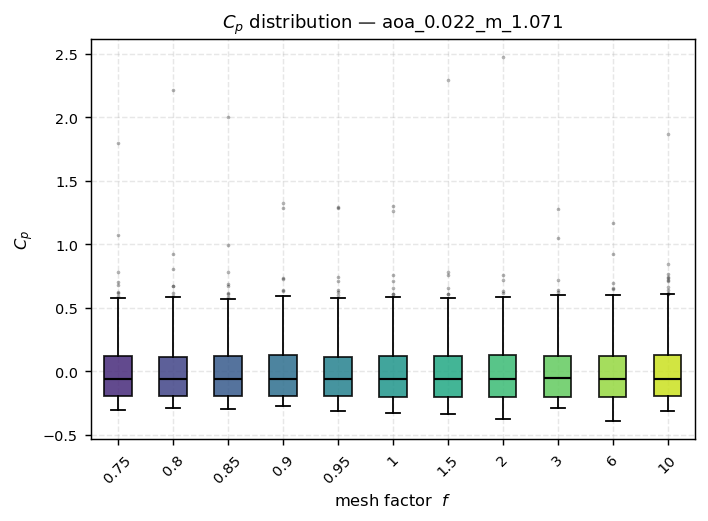

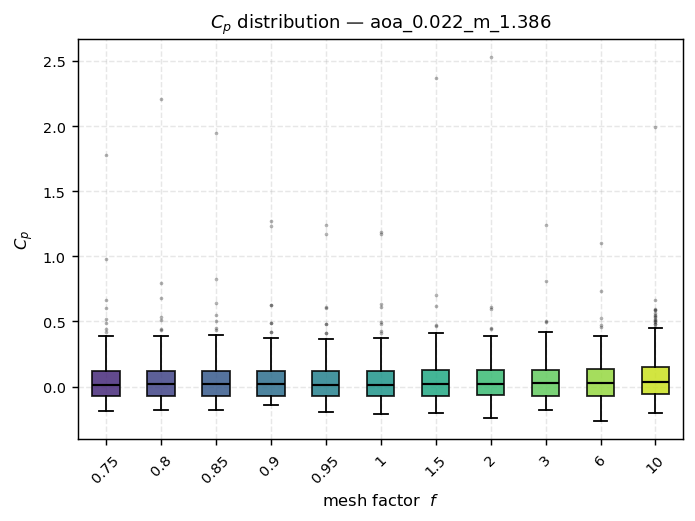

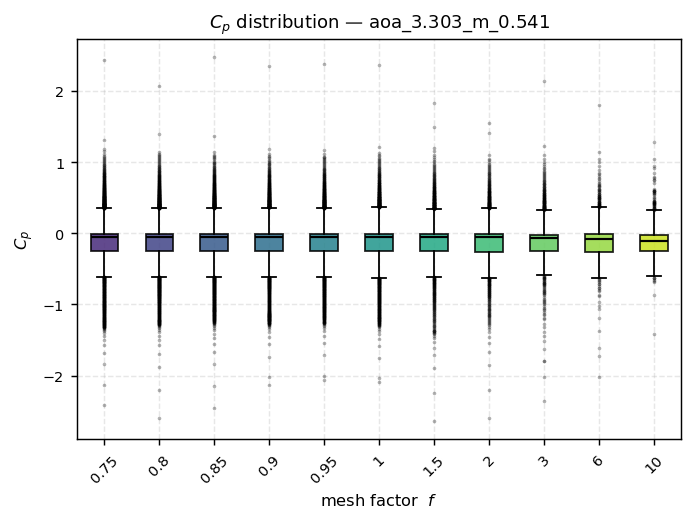

Distribution of wall C<sub>p</sub> for each mesh (darker = finer mesh).

# 4. GCI on the integral coefficients

The classic target of a convergence study: one integral quantity per mesh, taken from the solver's own monitors. This section is where the study stops describing and starts deciding — it ends with a single recommended mesh.

aoa_0.022_m_1.071

| case | f | CoefLift | CoefDrag | CoefMomentY |
| --- | --- | --- | --- | --- |
| f0.75 | 0.75 | 0.0019669 | 0.039322 | -0.00021913 |
| f0.8 | 0.8 | 0.0031299 | 0.039673 | -0.00057038 |
| f0.85 | 0.85 | 0.0022783 | 0.039916 | -0.00033684 |
| f0.9 | 0.9 | 0.0031643 | 0.040403 | -0.00062186 |
| f0.95 | 0.95 | 0.0020549 | 0.040704 | -0.00033975 |
| f1 | 1 | 0.0037024 | 0.041088 | -0.00093572 |
| f1.5 | 1.5 | 0.0021934 | 0.04382 | -0.00052295 |
| f2 | 2 | 0.0017215 | 0.046171 | -0.00032687 |
| f3 | 3 | 0.0037384 | 0.046198 | 0.00084134 |
| f6 | 6 | 0.003477 | 0.058565 | -0.0016306 |
| f10 | 10 | 0.0013854 | 0.076855 | -0.001156 |

aoa_0.022_m_1.386

| case | f | CoefLift | CoefDrag | CoefMomentY |
| --- | --- | --- | --- | --- |
| f0.75 | 0.75 | 0.0018225 | 0.027599 | -0.00027034 |
| f0.8 | 0.8 | 0.0020598 | 0.027889 | -0.0004185 |
| f0.85 | 0.85 | 0.0018518 | 0.02812 | -0.00022416 |
| f0.9 | 0.9 | 0.0020879 | 0.028527 | -0.00037592 |
| f0.95 | 0.95 | 0.0017543 | 0.028785 | -0.0002561 |
| f1 | 1 | 0.0021588 | 0.029123 | -0.00049178 |
| f1.5 | 1.5 | 0.0020833 | 0.03151 | -0.00045604 |
| f2 | 2 | 0.0025592 | 0.032624 | -0.00050131 |
| f3 | 3 | 0.0013129 | 0.033166 | 4.795e-05 |
| f6 | 6 | 0.0030865 | 0.044256 | -0.00050143 |
| f10 | 10 | 0.0056457 | 0.061782 | 0.00020581 |

aoa_3.303_m_0.541

| case | f | CoefLift | CoefDrag | CoefMomentY |
| --- | --- | --- | --- | --- |
| f0.75 | 0.75 | 0.34696 | 0.037437 | 0.0036059 |
| f0.8 | 0.8 | 0.34979 | 0.037718 | 0.0029791 |
| f0.85 | 0.85 | 0.34887 | 0.038271 | 0.0034559 |
| f0.9 | 0.9 | 0.3533 | 0.038562 | 0.0031187 |
| f0.95 | 0.95 | 0.35054 | 0.038984 | 0.0034289 |
| f1 | 1 | 0.35739 | 0.039384 | 0.0015884 |
| f1.5 | 1.5 | 0.34768 | 0.04337 | -0.00041256 |
| f2 | 2 | 0.34773 | 0.045955 | -0.0004188 |
| f3 | 3 | 0.33578 | 0.053302 | -0.00082522 |
| f6 | 6 | 0.3427 | 0.070862 | -0.0080743 |
| f10 | 10 | 0.31519 | 0.095795 | -0.0079788 |

Integral coefficients averaged over the last 1000 iterations of stage 1.

## 4.1 Converged simulations only

Before comparing meshes one has to be sure of comparing **solutions of the equations** rather than wherever each run happened to stop. With a final residual of order $10^{-1}$, the iterative error of a simulation exceeds the inter-mesh difference Richardson is trying to measure, and the extrapolation amplifies that noise.

The criterion is the one FotR already applies elsewhere in the library (`CODAResiduals.update_converged_state`): every normalised residual $r/r_0$ below 1e-04 at the end of the run.

> **`MomentumY` is left out of the criterion.** Its residual sits at ~0.8 on **every** mesh, including those reaching $10^{-6}$ in all other equations — the spanwise momentum equation is degenerate in this configuration. Requiring it to converge would flag the entire database as unconverged.

aoa_0.022_m_1.071

| case | f | iterations | max residual (r/r0) | converged | excluded (§2) |
| --- | --- | --- | --- | --- | --- |
| f0.75 | 0.75 | 7222 | 9.9e-06 | True | False |
| f0.8 | 0.8 | 15615 | 0.00223 | False | False |
| f0.85 | 0.85 | 15606 | 0.00138 | False | False |
| f0.9 | 0.9 | 6009 | 9.92e-06 | True | False |
| f0.95 | 0.95 | 5455 | 9.91e-06 | True | True |
| f1 | 1 | 5228 | 9.97e-06 | True | False |
| f1.5 | 1.5 | 15508 | 0.00469 | False | False |
| f2 | 2 | 2056 | 9.83e-06 | True | False |
| f3 | 3 | 15422 | 1.05 | False | False |
| f6 | 6 | 15317 | 1.29 | False | False |
| f10 | 10 | 15446 | 1.22 | False | False |

aoa_0.022_m_1.386

| case | f | iterations | max residual (r/r0) | converged | excluded (§2) |
| --- | --- | --- | --- | --- | --- |
| f0.75 | 0.75 | 7099 | 1e-05 | True | False |
| f0.8 | 0.8 | 7408 | 9.85e-06 | True | False |
| f0.85 | 0.85 | 6787 | 9.92e-06 | True | False |
| f0.9 | 0.9 | 6444 | 9.83e-06 | True | False |
| f0.95 | 0.95 | 5544 | 9.8e-06 | True | True |
| f1 | 1 | 5781 | 9.94e-06 | True | False |
| f1.5 | 1.5 | 4874 | 9.79e-06 | True | False |
| f2 | 2 | 1221 | 9.95e-06 | True | False |
| f3 | 3 | 15420 | 2.52 | False | False |
| f6 | 6 | 15318 | 2.55 | False | False |
| f10 | 10 | 532 | 8.32e-06 | True | False |

aoa_3.303_m_0.541

| case | f | iterations | max residual (r/r0) | converged | excluded (§2) |
| --- | --- | --- | --- | --- | --- |
| f0.75 | 0.75 | 10932 | 9.97e-06 | True | False |
| f0.8 | 0.8 | 12419 | 9.96e-06 | True | False |
| f0.85 | 0.85 | 10417 | 9.96e-06 | True | False |
| f0.9 | 0.9 | 11925 | 1e-05 | True | False |
| f0.95 | 0.95 | 11025 | 9.97e-06 | True | True |
| f1 | 1 | 7945 | 9.86e-06 | True | False |
| f1.5 | 1.5 | 4839 | 9.95e-06 | True | False |
| f2 | 2 | 4776 | 9.84e-06 | True | False |
| f3 | 3 | 2041 | 9.61e-06 | True | False |
| f6 | 6 | 1785 | 9.88e-06 | True | False |
| f10 | 10 | 1045 | 9.43e-06 | True | False |

Final residual per mesh and convergence verdict (threshold 1e-04).

Sensitivity of the filter to the convergence threshold

| threshold | aoa_0.022_m_1.071 | aoa_0.022_m_1.386 | aoa_3.303_m_0.541 | common | triplets |
| --- | --- | --- | --- | --- | --- |
| 1e-06 | 0 | 0 | 0 | 0 | 0 |
| 1e-05 | 4 | 8 | 10 | 4 | 4 |
| 1e-04 | 4 | 8 | 10 | 4 | 4 |
| 1e-03 | 4 | 8 | 10 | 4 | 4 |
| 5e-03 | 7 | 8 | 10 | 7 | 35 |

Meshes surviving in each database (f0.95 excluded), those common to all three, and the triplets they allow. Between 1e-4 and 1e-3 the set does not change: the choice of threshold does not drive the result.

That filter is what decides the study, and it is worth seeing why: one of the three flight conditions is left with very few meshes, and it is the one that ends up constraining everything else.

## 4.2 Every admissible triplet, scored

A GCI triplet need not be built from **adjacent** meshes. All Richardson requires is three distinct, ordered sizes; quality is set by the refinement ratio, not by adjacency. Restricting the study to windows of three neighbours is exactly what would guarantee refinement steps of 5 % here. So **every combination of three converged meshes** is enumerated, $\binom{n}{3}$ per flight condition.

### Rejected versus penalised

A triplet is **rejected** — it does not appear at all — only when the extrapolation is inapplicable:

- one of the three meshes did not converge, or is `f0.95`;
- the observed order does not resolve: null differences, or oscillatory convergence;
- $r_{21} \leq 1$ or $r_{32} \leq 1$, which is not a refinement.

Everything else is **penalised** through a score rather than silently removed. That choice matters: a hard plausibility band on $p$ would hide candidates instead of ranking them, and the edge of such a band is always arbitrary.

### The score

Five terms in $[0,1]$, higher is better:

| term | measures | weight |
| --- | --- | --- |
| $1/(1+\lvert AR-1\rvert)$ | asymptotic ratio near 1 — the hypothesis the extrapolation rests on | 0.35 |
| $1/(1+\lvert p-2\rvert/2)$ | observed order near the nominal second order of the scheme | 0.25 |
| $\mathrm{clip}(\min(r_{21},r_{32})-1,\,0,\,1)$ | refinement above the iterative noise, saturating at $r=2$ | 0.20 |
| $\min(r)/\max(r)$ | balanced steps, as Roache recommends | 0.10 |
| normalised, inverted $h_1$ | the fine mesh, where the reported value lives | 0.10 |

> **The GCI is deliberately not a term.** Ranking by the GCI selects the smallest estimate; across a hundred candidates that is fishing, not measuring. The order term is what handles the $p \approx 10$ triplets: it sinks them to the bottom of the ranking without a filter to hide them.

The weights live in `SCORE_WEIGHTS` and are open to argument; what should not change is the exclusion of the GCI itself.

How many triplets survive at each flight condition

| database | converged meshes | combinations | admissible triplets | with p in [0.5, 4.0] |
| --- | --- | --- | --- | --- |
| aoa_0.022_m_1.071 | 4 | 4 | 2 | 1 |
| aoa_0.022_m_1.386 | 8 | 56 | 21 | 13 |
| aoa_3.303_m_0.541 | 10 | 120 | 61 | 51 |

Enumeration on **CoefDrag**. The last column is informational: the observed order is penalised, not filtered.

aoa_0.022_m_1.071

| rank | triplet (fine / medium / coarse) | r21 | r32 | p | asympt. ratio | GCI [%] | asympt. | order | refin. | balance | fineness | SCORE |
| --- | --- | --- | --- | --- | --- | --- | --- | --- | --- | --- | --- | --- |
| 1 | f0.75 / f1 / f2 | 1.333 | 2 | 0.3587 | 0.957 | 51.63 | 0.9588 | 0.5493 | 0.3333 | 0.6667 | 1 | 0.7062 |
| 2 | f0.75 / f0.9 / f1 | 1.2 | 1.111 | 0.6458 | 0.9733 | 27.49 | 0.974 | 0.5963 | 0.1111 | 0.9259 | 1 | 0.7048 |

aoa_0.022_m_1.386

| rank | triplet (fine / medium / coarse) | r21 | r32 | p | asympt. ratio | GCI [%] | asympt. | order | refin. | balance | fineness | SCORE |
| --- | --- | --- | --- | --- | --- | --- | --- | --- | --- | --- | --- | --- |
| 1 | f0.75 / f2 / f10 | 2.667 | 5 | 0.931 | 0.846 | 15.25 | 0.8665 | 0.6517 | 1 | 0.5333 | 1 | 0.8195 |
| 2 | f0.75 / f0.8 / f0.9 | 1.067 | 1.125 | 2.041 | 0.9896 | 9.321 | 0.9897 | 0.9799 | 0.06667 | 0.9481 | 1 | 0.7995 |
| 3 | f0.8 / f2 / f10 | 2.5 | 5 | 0.9432 | 0.8549 | 15.45 | 0.8733 | 0.6543 | 1 | 0.5 | 0.8 | 0.7992 |
| 4 | f0.85 / f2 / f10 | 2.353 | 5 | 0.9478 | 0.862 | 16.01 | 0.8787 | 0.6553 | 1 | 0.4706 | 0.6 | 0.7784 |
| 5 | f0.9 / f2 / f10 | 2.222 | 5 | 0.9841 | 0.8744 | 15.03 | 0.8884 | 0.6631 | 1 | 0.4444 | 0.4 | 0.7612 |
| 6 | f0.75 / f0.85 / f1 | 1.133 | 1.176 | 2.713 | 0.9815 | 5.836 | 0.9818 | 0.7371 | 0.1333 | 0.9633 | 1 | 0.7509 |
| 7 | f0.75 / f1 / f1.5 | 1.333 | 1.5 | 0.3033 | 0.9477 | 75.7 | 0.9503 | 0.541 | 0.3333 | 0.8889 | 1 | 0.7234 |
| 8 | f0.75 / f0.9 / f1 | 1.2 | 1.111 | 0.7429 | 0.9675 | 28.97 | 0.9685 | 0.614 | 0.1111 | 0.9259 | 1 | 0.7073 |
| 9 | f0.75 / f0.8 / f0.85 | 1.067 | 1.062 | 2.443 | 0.722 | 7.686 | 0.7825 | 0.8188 | 0.0625 | 0.9961 | 1 | 0.6907 |
| 10 | f0.8 / f0.9 / f1 | 1.125 | 1.111 | 0.3931 | 0.9776 | 60.34 | 0.9781 | 0.5545 | 0.1111 | 0.9877 | 0.8 | 0.682 |
| 11 | f0.8 / f1 / f1.5 | 1.25 | 1.5 | 0.1975 | 0.9576 | 122.8 | 0.9593 | 0.526 | 0.25 | 0.8333 | 0.8 | 0.6806 |
| 12 | f0.75 / f1 / f2 | 1.333 | 2 | 0.6432 | 0.6545 | 33.96 | 0.7432 | 0.5958 | 0.3333 | 0.6667 | 1 | 0.6424 |
| 13 | f0.75 / f0.85 / f0.9 | 1.133 | 1.059 | 6.087 | 0.9815 | 2.066 | 0.9818 | 0.3286 | 0.05882 | 0.9343 | 1 | 0.631 |
| 14 | f0.85 / f1 / f1.5 | 1.176 | 1.5 | 1.439 | 0.6049 | 16.92 | 0.7168 | 0.7809 | 0.1765 | 0.7843 | 0.6 | 0.6198 |
| 15 | f0.75 / f1.5 / f2 | 2 | 1.333 | 0.4172 | 0.4912 | 52.83 | 0.6628 | 0.5582 | 0.3333 | 0.6667 | 1 | 0.6049 |
| 16 | f0.8 / f1.5 / f2 | 1.875 | 1.333 | 0.4933 | 0.476 | 44.64 | 0.6562 | 0.5703 | 0.3333 | 0.7111 | 0.8 | 0.59 |
| 17 | f0.8 / f0.85 / f0.9 | 1.062 | 1.059 | 10.61 | 0.9918 | 1.149 | 0.9918 | 0.1885 | 0.05882 | 0.9965 | 0.8 | 0.5857 |
| 18 | f0.85 / f1.5 / f2 | 1.765 | 1.333 | 0.606 | 0.4483 | 36.68 | 0.6445 | 0.5893 | 0.3333 | 0.7556 | 0.6 | 0.5751 |
| 19 | f0.9 / f1.5 / f2 | 1.667 | 1.333 | 0.6553 | 0.4635 | 32.88 | 0.6508 | 0.598 | 0.3333 | 0.8 | 0.4 | 0.5639 |
| 20 | f1 / f1.5 / f2 | 1.5 | 1.333 | 0.8965 | 0.4467 | 23.37 | 0.6438 | 0.6444 | 0.3333 | 0.8889 | 0 | 0.542 |
| 21 | f0.85 / f0.9 / f1 | 1.059 | 1.111 | 7.469 | 0.4197 | 3.395 | 0.6328 | 0.2678 | 0.05882 | 0.9529 | 0.6 | 0.4555 |

aoa_3.303_m_0.541

| rank | triplet (fine / medium / coarse) | r21 | r32 | p | asympt. ratio | GCI [%] | asympt. | order | refin. | balance | fineness | SCORE |
| --- | --- | --- | --- | --- | --- | --- | --- | --- | --- | --- | --- | --- |
| 1 | f0.75 / f1.5 / f3 | 2 | 2 | 0.7434 | 0.8632 | 29.38 | 0.8797 | 0.6141 | 1 | 1 | 1 | 0.8614 |
| 2 | f0.75 / f2 / f6 | 2.667 | 3 | 0.9148 | 0.8146 | 19.57 | 0.8436 | 0.6483 | 1 | 0.8889 | 1 | 0.8462 |
| 3 | f0.8 / f2 / f6 | 2.5 | 3 | 0.9059 | 0.8208 | 21.1 | 0.848 | 0.6464 | 1 | 0.8333 | 0.9778 | 0.8395 |
| 4 | f0.85 / f2 / f6 | 2.353 | 3 | 0.9305 | 0.8328 | 20.62 | 0.8567 | 0.6516 | 1 | 0.7843 | 0.9556 | 0.8367 |
| 5 | f0.9 / f2 / f6 | 2.222 | 3 | 0.9231 | 0.8391 | 21.99 | 0.8614 | 0.65 | 1 | 0.7407 | 0.9333 | 0.8314 |
| 6 | f0.8 / f1.5 / f3 | 1.875 | 2 | 0.7026 | 0.8697 | 33.73 | 0.8847 | 0.6065 | 0.875 | 0.9375 | 0.9778 | 0.8278 |
| 7 | f0.9 / f3 / f10 | 3.333 | 3.333 | 0.8794 | 0.7235 | 25.38 | 0.7834 | 0.6409 | 1 | 1 | 0.9333 | 0.8277 |
| 8 | f1 / f2 / f6 | 2 | 3 | 0.9435 | 0.857 | 22.59 | 0.8749 | 0.6543 | 1 | 0.6667 | 0.8889 | 0.8254 |
| 9 | f0.85 / f3 / f10 | 3.529 | 3.333 | 0.8844 | 0.718 | 23.94 | 0.78 | 0.6419 | 1 | 0.9444 | 0.9556 | 0.8235 |
| 10 | f1.5 / f3 / f6 | 2 | 2 | 0.8222 | 0.8137 | 37.27 | 0.8429 | 0.6294 | 1 | 1 | 0.6667 | 0.819 |
| 11 | f0.8 / f3 / f10 | 3.75 | 3.333 | 0.8756 | 0.7076 | 23.68 | 0.7738 | 0.6401 | 1 | 0.8889 | 0.9778 | 0.8175 |
| 12 | f1 / f3 / f10 | 3 | 3.333 | 0.8832 | 0.7389 | 26.96 | 0.7929 | 0.6417 | 1 | 0.9 | 0.8889 | 0.8168 |
| 13 | f0.75 / f3 / f10 | 4 | 3.333 | 0.8811 | 0.7024 | 22.14 | 0.7706 | 0.6413 | 1 | 0.8333 | 1 | 0.8134 |
| 14 | f0.75 / f1.5 / f6 | 2 | 4 | 0.774 | 0.8632 | 27.9 | 0.8797 | 0.62 | 1 | 0.5 | 1 | 0.8129 |
| 15 | f0.75 / f2 / f10 | 2.667 | 5 | 0.9368 | 0.8146 | 18.88 | 0.8436 | 0.6529 | 1 | 0.5333 | 1 | 0.8118 |
| 16 | f0.8 / f2 / f10 | 2.5 | 5 | 0.9306 | 0.8208 | 20.28 | 0.848 | 0.6516 | 1 | 0.5 | 0.9778 | 0.8075 |
| 17 | f0.85 / f2 / f10 | 2.353 | 5 | 0.9491 | 0.8328 | 20.04 | 0.8567 | 0.6555 | 1 | 0.4706 | 0.9556 | 0.8064 |
| 18 | f0.85 / f1.5 / f3 | 1.765 | 2 | 0.7359 | 0.8824 | 32.09 | 0.8948 | 0.6127 | 0.7647 | 0.8824 | 0.9556 | 0.8031 |
| 19 | f0.9 / f2 / f10 | 2.222 | 5 | 0.944 | 0.8391 | 21.3 | 0.8614 | 0.6544 | 1 | 0.4444 | 0.9333 | 0.8029 |
| 20 | f1.5 / f2 / f3 | 1.333 | 1.5 | 1.985 | 0.9437 | 9.676 | 0.9467 | 0.9925 | 0.3333 | 0.8889 | 0.6667 | 0.8017 |
| 21 | f1 / f2 / f10 | 2 | 5 | 0.9594 | 0.857 | 22.08 | 0.8749 | 0.6578 | 1 | 0.4 | 0.8889 | 0.7995 |
| 22 | f1 / f3 / f6 | 3 | 2 | 0.7947 | 0.7389 | 31.68 | 0.7929 | 0.624 | 1 | 0.6667 | 0.8889 | 0.7891 |
| 23 | f1.5 / f3 / f10 | 2 | 3.333 | 0.9151 | 0.8137 | 32.32 | 0.8429 | 0.6483 | 1 | 0.6 | 0.6667 | 0.7838 |
| 24 | f0.9 / f3 / f6 | 3.333 | 2 | 0.7932 | 0.7235 | 29.89 | 0.7834 | 0.6237 | 1 | 0.6 | 0.9333 | 0.7834 |
| 25 | f0.8 / f1.5 / f6 | 1.875 | 4 | 0.7501 | 0.8697 | 31.09 | 0.8847 | 0.6154 | 0.875 | 0.4688 | 0.9778 | 0.7832 |
| 26 | f0.85 / f3 / f6 | 3.529 | 2 | 0.8018 | 0.718 | 28.07 | 0.78 | 0.6254 | 1 | 0.5667 | 0.9556 | 0.7816 |
| 27 | f0.8 / f3 / f6 | 3.75 | 2 | 0.7917 | 0.7076 | 27.95 | 0.7738 | 0.6234 | 1 | 0.5333 | 0.9778 | 0.7778 |
| 28 | f0.9 / f1.5 / f3 | 1.667 | 2 | 0.691 | 0.8891 | 36.82 | 0.9002 | 0.6044 | 0.6667 | 0.8333 | 0.9333 | 0.7762 |
| 29 | f0.75 / f3 / f6 | 4 | 2 | 0.8009 | 0.7024 | 26.03 | 0.7706 | 0.6252 | 1 | 0.5 | 1 | 0.776 |
| 30 | f0.75 / f0.9 / f1 | 1.2 | 1.111 | 1.646 | 0.9708 | 10.73 | 0.9717 | 0.8496 | 0.1111 | 0.9259 | 1 | 0.7673 |
| 31 | f0.75 / f1 / f1.5 | 1.333 | 1.5 | 1.067 | 0.9506 | 18.09 | 0.9529 | 0.6819 | 0.3333 | 0.8889 | 1 | 0.7595 |
| 32 | f1 / f2 / f3 | 2 | 1.5 | 1.214 | 0.857 | 15.8 | 0.8749 | 0.7179 | 0.5 | 0.75 | 0.8889 | 0.7496 |
| 33 | f0.9 / f2 / f3 | 2.222 | 1.5 | 1.159 | 0.8391 | 15.74 | 0.8614 | 0.704 | 0.5 | 0.675 | 0.9333 | 0.7383 |
| 34 | f0.85 / f2 / f3 | 2.353 | 1.5 | 1.163 | 0.8328 | 14.71 | 0.8567 | 0.7051 | 0.5 | 0.6375 | 0.9556 | 0.7354 |
| 35 | f1 / f1.5 / f3 | 1.5 | 2 | 0.6749 | 0.9081 | 40.19 | 0.9158 | 0.6015 | 0.5 | 0.75 | 0.8889 | 0.7348 |
| 36 | f0.85 / f1 / f1.5 | 1.176 | 1.5 | 1.243 | 0.9717 | 16.24 | 0.9725 | 0.7254 | 0.1765 | 0.7843 | 0.9556 | 0.731 |
| 37 | f0.8 / f2 / f3 | 2.5 | 1.5 | 1.113 | 0.8208 | 15.4 | 0.848 | 0.6927 | 0.5 | 0.6 | 0.9778 | 0.7278 |
| 38 | f0.8 / f1 / f1.5 | 1.25 | 1.5 | 0.8651 | 0.9577 | 25.92 | 0.9594 | 0.638 | 0.25 | 0.8333 | 0.9778 | 0.7264 |
| 39 | f0.75 / f2 / f3 | 2.667 | 1.5 | 1.121 | 0.8146 | 14.21 | 0.8436 | 0.6946 | 0.5 | 0.5625 | 1 | 0.7252 |
| 40 | f0.75 / f1 / f2 | 1.333 | 2 | 0.6726 | 0.9506 | 30.44 | 0.9529 | 0.6011 | 0.3333 | 0.6667 | 1 | 0.7171 |
| 41 | f0.8 / f0.9 / f1 | 1.125 | 1.111 | 0.76 | 0.9781 | 29.87 | 0.9786 | 0.6173 | 0.1111 | 0.9877 | 0.9778 | 0.7156 |
| 42 | f0.75 / f0.85 / f1 | 1.133 | 1.176 | 0.1904 | 0.9782 | 115.4 | 0.9787 | 0.525 | 0.1333 | 0.9633 | 1 | 0.6968 |
| 43 | f0.75 / f0.85 / f0.9 | 1.133 | 1.059 | 1.678 | 0.6427 | 11.91 | 0.7367 | 0.8614 | 0.05882 | 0.9343 | 1 | 0.6784 |
| 44 | f0.85 / f1.5 / f2 | 1.765 | 1.333 | 0.002501 | 0.8824 | 1.172e+04 | 0.8948 | 0.5003 | 0.3333 | 0.7556 | 0.9556 | 0.676 |
| 45 | f2 / f3 / f6 | 1.5 | 2 | 0.6016 | 0.8622 | 72.34 | 0.8789 | 0.5885 | 0.5 | 0.75 | 0.4444 | 0.6742 |
| 46 | f0.8 / f1.5 / f2 | 1.875 | 1.333 | 0.0005607 | 0.8691 | 5.313e+04 | 0.8842 | 0.5001 | 0.3333 | 0.7111 | 0.9778 | 0.6701 |
| 47 | f3 / f6 / f10 | 2 | 1.667 | 1.108 | 0.7522 | 35.65 | 0.8014 | 0.6915 | 0.6667 | 0.8333 | 0 | 0.67 |
| 48 | f0.75 / f1.5 / f2 | 2 | 1.333 | 0.09978 | 0.8632 | 276.6 | 0.8797 | 0.5128 | 0.3333 | 0.6667 | 1 | 0.6694 |
| 49 | f0.9 / f1.5 / f2 | 1.667 | 1.333 | 0.07419 | 0.8242 | 403.5 | 0.8505 | 0.5094 | 0.3333 | 0.8 | 0.9333 | 0.665 |
| 50 | f1.5 / f6 / f10 | 4 | 1.667 | 1.025 | 0.612 | 25.24 | 0.7205 | 0.6722 | 0.6667 | 0.4167 | 0.6667 | 0.6619 |
| 51 | f1 / f1.5 / f2 | 1.5 | 1.333 | 0.1931 | 0.7765 | 155.3 | 0.8173 | 0.5254 | 0.3333 | 0.8889 | 0.8889 | 0.6618 |
| 52 | f2 / f6 / f10 | 3 | 1.667 | 1.001 | 0.6485 | 33.8 | 0.7399 | 0.667 | 0.6667 | 0.5556 | 0.4444 | 0.6591 |
| 53 | f1 / f6 / f10 | 6 | 1.667 | 0.9891 | 0.5558 | 20.46 | 0.6924 | 0.6643 | 0.6667 | 0.2778 | 0.8889 | 0.6584 |
| 54 | f0.85 / f6 / f10 | 7.059 | 1.667 | 0.9841 | 0.5401 | 18.22 | 0.685 | 0.6632 | 0.6667 | 0.2361 | 0.9556 | 0.658 |
| 55 | f0.9 / f6 / f10 | 6.667 | 1.667 | 0.9831 | 0.5442 | 19.19 | 0.6869 | 0.6629 | 0.6667 | 0.25 | 0.9333 | 0.6578 |
| 56 | f0.75 / f6 / f10 | 8 | 1.667 | 0.9784 | 0.5283 | 16.79 | 0.6795 | 0.6619 | 0.6667 | 0.2083 | 1 | 0.6575 |
| 57 | f0.8 / f6 / f10 | 7.5 | 1.667 | 0.977 | 0.5323 | 17.83 | 0.6813 | 0.6616 | 0.6667 | 0.2222 | 0.9778 | 0.6572 |
| 58 | f0.75 / f0.8 / f0.9 | 1.067 | 1.125 | 5.339 | 0.9926 | 2.28 | 0.9926 | 0.3746 | 0.06667 | 0.9481 | 1 | 0.6492 |
| 59 | f0.85 / f0.9 / f1 | 1.059 | 1.111 | 5.138 | 0.9925 | 2.785 | 0.9925 | 0.3892 | 0.05882 | 0.9529 | 0.9556 | 0.6473 |
| 60 | f0.75 / f0.8 / f0.85 | 1.067 | 1.062 | 11.86 | 0.9926 | 0.8159 | 0.9926 | 0.1686 | 0.0625 | 0.9961 | 1 | 0.6017 |
| 61 | f0.8 / f0.85 / f0.9 | 1.062 | 1.059 | 9.318 | 0.3184 | 2.413 | 0.5947 | 0.2146 | 0.05882 | 0.9965 | 0.9778 | 0.471 |

Every admissible triplet, ordered by score. The five middle columns are the components; the last is their weighted combination. The GCI is shown but takes no part in the ordering.

### What the filter changes, and what it does not

The plot below compares the GCI distribution **before and after** the convergence filter, over the same flight conditions. It is worth reading without assuming the answer.

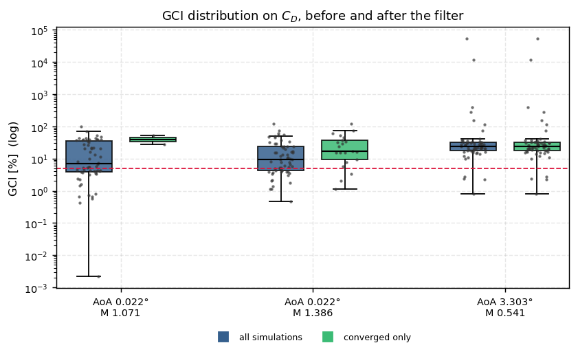

Each point is a triplet. The filter cuts the number of candidates, but wherever enough survive the distribution barely narrows.

The outcome is not the expected one. **Filtering by convergence discards candidates but does not explain the scatter.** In the condition where almost every simulation converges, the distribution before and after is essentially the same: were iterative noise the cause, there would be scatter to remove there. Where the distribution narrows sharply it does so only because two or three candidates remain, not because they agree.

The conclusion is awkward but useful: **iterative error is not the main driver of the scatter.** Almost certainly the driver is that the solutions are not in the asymptotic range over this family — which the observed orders of §4.4 will confirm.

The filter stays, because a triplet built on a half-converged simulation is indefensible however attractive its GCI. But it is worth knowing what it fixes and what it does not.

## 4.3 Consensus across flight conditions

A mesh that is good at one flight point is of no use: the choice has to hold at all three. The procedure is direct:

1. within each condition, rank the triplets by score;
2. take the **top $n$** of each and intersect;
3. increase $n$ until the intersection is non-empty. That $n^\*$ and those triplets are the candidates.

> This is not an arbitrary recipe: **the first triplet to enter the intersection is exactly the one whose worst rank across the three conditions is smallest.** The sweep is therefore a *minimax* selection — it picks the triplet whose behaviour at its least favourable condition is the best available. That is the right criterion when what is wanted is a mesh that does not fail at any flight point.

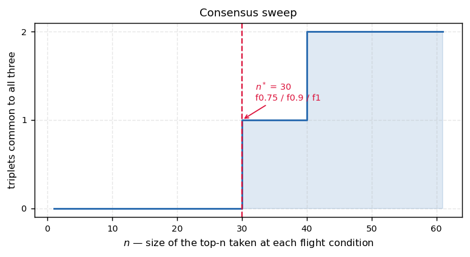

The intersection of the three rankings stays empty up to n* and grows from there. The first element to appear is the winning triplet.

Consensus candidates (n* = 30)

| triplet | rank 0.022 / M1.071 | score 0.022 / M1.071 | rank 0.022 / M1.386 | score 0.022 / M1.386 | rank 3.303 / M0.541 | score 3.303 / M0.541 | worst rank | worst score |
| --- | --- | --- | --- | --- | --- | --- | --- | --- |
| f0.75 / f0.9 / f1 | 2 | 0.7048 | 8 | 0.7073 | 30 | 0.7673 | 30 | 0.7048 |

Ordered by their worst rank across the three flight conditions. The first row is the winning triplet.

## 4.4 The winning triplet

Winning triplet: f0.75 / f0.9 / f1

| database | rank | r21 | r32 | observed p | CoefDrag on fine mesh | extrapolated | GCI [%] | asympt. ratio | score |
| --- | --- | --- | --- | --- | --- | --- | --- | --- | --- |
| aoa_0.022_m_1.071 | 2 | 1.2 | 1.1111 | 0.64577 | 0.039322 | 0.030674 | 27.491 | 0.97325 | 0.70476 |
| aoa_0.022_m_1.386 | 8 | 1.2 | 1.1111 | 0.74288 | 0.027599 | 0.021203 | 28.97 | 0.96748 | 0.7073 |
| aoa_3.303_m_0.541 | 30 | 1.2 | 1.1111 | 1.6459 | 0.037437 | 0.034223 | 10.732 | 0.97083 | 0.76729 |

Behaviour of the triplet at each flight condition, on CoefDrag.

### Cross-check against the other two coefficients

The decision rests on a single coefficient. It remains to see whether the winner also behaves reasonably for the other two — bearing in mind that at low angle of attack their relative GCI is meaningless, since the coefficient passes close to zero.

The winner f0.75 / f0.9 / f1 seen through all three coefficients

| database | p CL | GCI CL [%] | p CD | GCI CD [%] | p CMy | GCI CMy [%] |
| --- | --- | --- | --- | --- | --- | --- |
| aoa_0.022_m_1.071 | 1.134 | 331.2 | 0.6458 | 27.49 | 2.107 | 490.4 |
| aoa_0.022_m_1.386 | 3.442 | 20.84 | 0.7429 | 28.97 | 4.592 | 37.26 |
| aoa_3.303_m_0.541 | 0.7694 | 15.17 | 1.646 | 10.73 | 12.76 | 1.829 |

CL and CMy are ~1e-3 at the two low angle-of-attack conditions, so their relative GCI blows up there without the absolute error being large. The decision rests on CD.

## 4.5 Recommended mesh

Of the winning triplet, the mesh delivered is **the fine one**: it is the only one whose uncertainty the computed GCI bounds, since the Richardson band is built around its value.

Recommended mesh: f0.75

| database | mesh | wall cells | CoefDrag computed | extrapolated (h→0) | GCI [%] | band ± |
| --- | --- | --- | --- | --- | --- | --- |
| aoa_0.022_m_1.071 | f0.75 | 8181 | 0.039322 | 0.030674 | 27.491 | 0.0084327 |
| aoa_0.022_m_1.386 | f0.75 | 8181 | 0.027599 | 0.021203 | 28.97 | 0.0061425 |
| aoa_3.303_m_0.541 | f0.75 | 8181 | 0.037437 | 0.034223 | 10.732 | 0.0036727 |

Value of CoefDrag on the recommended mesh, its extrapolation to zero cell size, and the associated uncertainty band.

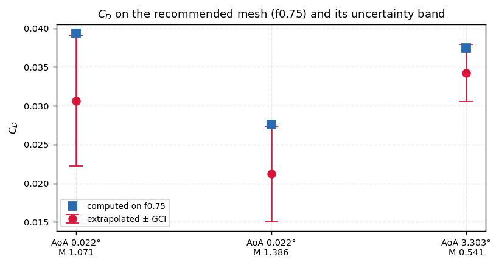

Blue square: the value the recommended mesh gives. Red bar: the extrapolated value with its GCI band. The gap between them is what still depends on the discretisation.

> **Caveat attached to the result.** The winner is the best of what is available, not good in absolute terms: its observed orders fall below the nominal second order of the scheme, and its GCI runs to several tens of per cent at two of the three conditions. The method delivers the best mesh these data support; **it does not demonstrate that the solution is mesh-converged.** §7 sets out what would be needed for that.

# 5. Convergence curves

Each coefficient against the mesh factor, over the **whole** family: nothing is filtered here, because which simulation converged and which did not is part of the diagnosis. Unconverged runs are drawn with an open marker.

Overlaid on them is the **winning triplet of §4.3** with its extrapolated value and GCI band, computed on the decision variable.

aoa_0.022_m_1.071

aoa_0.022_m_1.386

aoa_3.303_m_0.541

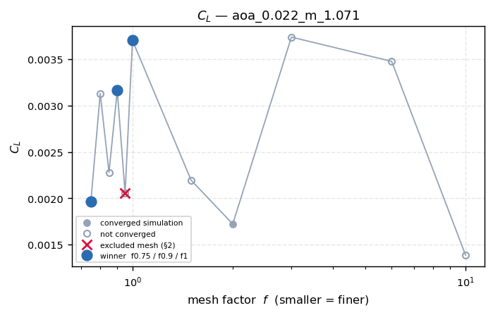

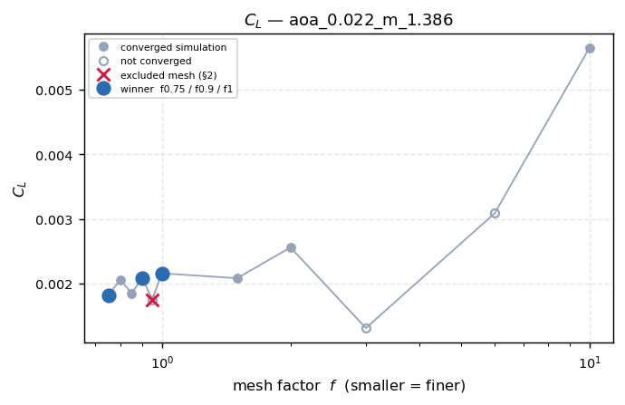

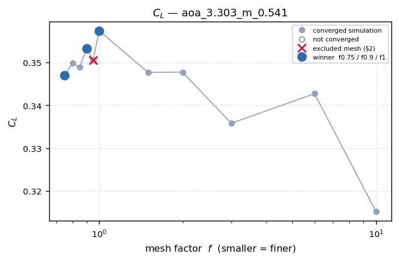

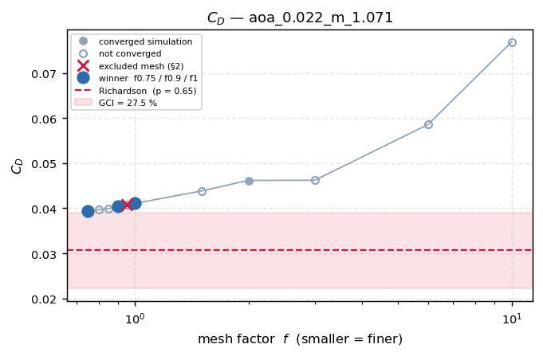

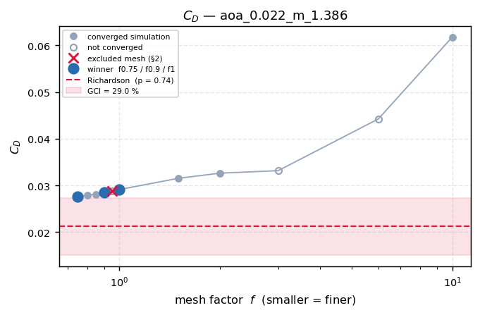

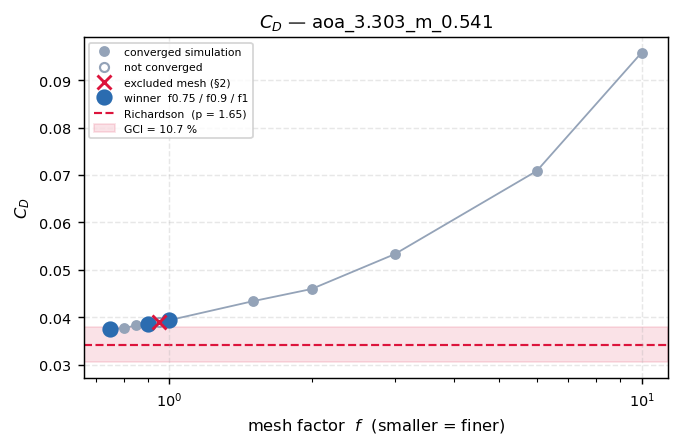

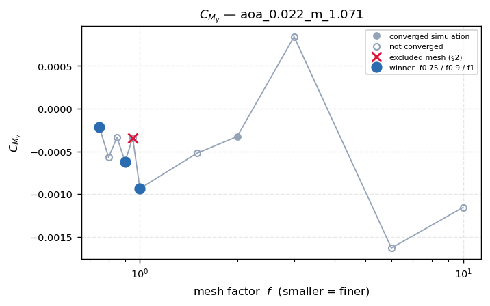

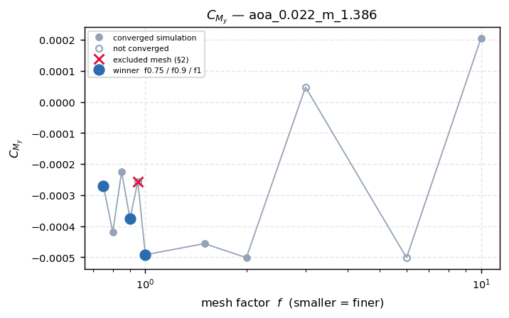

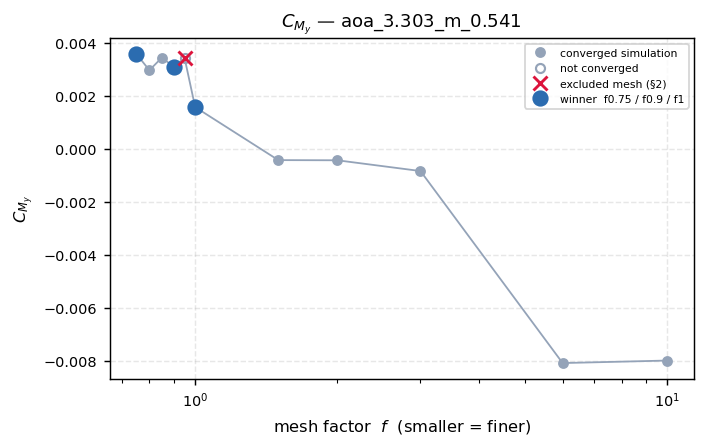

Mesh convergence of the integral coefficients. Rows: C<sub>L</sub>, C<sub>D</sub>, C<sub>My</sub>. Open marker: the simulation did not reach the convergence threshold. In blue, the winning triplet; the red band is drawn only on the decision variable.

# 6. Cross-check on a surface field

Everything so far rests on an integral the solver itself computes. It remains to see whether the choice holds when starting from an unrelated quantity: a reduction of the wall $C_p$ field.

The same filters as §4 apply — converged simulations only, no `f0.95` — and the same score.

aoa_0.022_m_1.071

| notice |
| --- |
| no admissible triplet on RMS(Cp) after the convergence filter |

aoa_0.022_m_1.386

| rank | triplet | r21 | r32 | p | RMS fine | extrapolated | GCI [%] | asympt. ratio | score |
| --- | --- | --- | --- | --- | --- | --- | --- | --- | --- |
| 1 | f0.75 / f2 / f10 | 2.667 | 5 | 0.6506 | 0.1182 | 0.107 | 11.83 | 0.9221 | 0.8273 |
| 2 | f0.8 / f2 / f10 | 2.5 | 5 | 0.6889 | 0.1192 | 0.1089 | 10.77 | 0.9296 | 0.808 |
| 3 | f0.85 / f2 / f10 | 2.353 | 5 | 0.6158 | 0.1187 | 0.1051 | 14.37 | 0.9261 | 0.7807 |
| 4 | f0.9 / f2 / f10 | 2.222 | 5 | 0.5697 | 0.1187 | 0.1021 | 17.44 | 0.9256 | 0.756 |
| 5 | f0.75 / f1 / f1.5 | 1.333 | 1.5 | 3.838 | 0.1182 | 0.1177 | 0.5035 | 0.9919 | 0.7331 |
| 6 | f0.75 / f1.5 / f2 | 2 | 1.333 | 0.6926 | 0.1182 | 0.1079 | 10.86 | 0.9492 | 0.7176 |
| 7 | f0.8 / f1.5 / f2 | 1.875 | 1.333 | 0.893 | 0.1192 | 0.112 | 7.479 | 0.9569 | 0.7142 |
| 8 | f1 / f2 / f10 | 2 | 5 | 0.5221 | 0.1192 | 0.09846 | 21.73 | 0.9295 | 0.7107 |
| 9 | f0.85 / f1.5 / f2 | 1.765 | 1.333 | 0.5171 | 0.1187 | 0.1017 | 17.92 | 0.9534 | 0.6802 |
| 10 | f0.75 / f0.9 / f1 | 1.2 | 1.111 | 4.654 | 0.1182 | 0.1179 | 0.3606 | 0.9962 | 0.6709 |
| 11 | f0.9 / f1.5 / f2 | 1.667 | 1.333 | 0.2548 | 0.1187 | 0.0764 | 44.53 | 0.9528 | 0.6544 |
| 12 | f0.8 / f0.9 / f1 | 1.125 | 1.111 | 0.02817 | 0.1192 | 0.2714 | 159.7 | 1.115 | 0.6407 |
| 13 | f1 / f1.5 / f2 | 1.5 | 1.333 | 0.0861 | 0.1192 | -0.03201 | 158.6 | 0.8923 | 0.5993 |
| 14 | f0.75 / f0.85 / f1 | 1.133 | 1.176 | 4.15 | 0.1182 | 0.1174 | 0.8096 | 0.3523 | 0.5559 |
| 15 | f0.8 / f0.85 / f1 | 1.062 | 1.176 | 0.4837 | 0.1192 | 0.134 | 15.52 | 0.3532 | 0.5375 |
| 16 | f0.75 / f0.8 / f0.85 | 1.067 | 1.062 | 11.63 | 0.1182 | 0.1174 | 0.9096 | 0.2341 | 0.4533 |
| 17 | f0.75 / f0.85 / f0.9 | 1.133 | 1.059 | 11.79 | 0.1182 | 0.1181 | 0.1635 | 0.1007 | 0.4319 |

aoa_3.303_m_0.541

| rank | triplet | r21 | r32 | p | RMS fine | extrapolated | GCI [%] | asympt. ratio | score |
| --- | --- | --- | --- | --- | --- | --- | --- | --- | --- |
| 1 | f0.75 / f1.5 / f3 | 2 | 2 | 1.586 | 0.2901 | 0.2918 | 0.7486 | 1.012 | 0.9529 |
| 2 | f0.8 / f1.5 / f3 | 1.875 | 2 | 1.579 | 0.2899 | 0.2919 | 0.839 | 1.012 | 0.9191 |
| 3 | f0.75 / f2 / f6 | 2.667 | 3 | 0.7576 | 0.2901 | 0.2957 | 2.423 | 1.022 | 0.8856 |
| 4 | f0.85 / f1.5 / f3 | 1.765 | 2 | 1.475 | 0.2899 | 0.2925 | 1.095 | 1.012 | 0.8807 |
| 5 | f0.8 / f2 / f6 | 2.5 | 3 | 0.7399 | 0.2899 | 0.2961 | 2.68 | 1.021 | 0.8772 |
| 6 | f0.85 / f3 / f10 | 3.529 | 3.333 | 0.6622 | 0.2899 | 0.3005 | 4.549 | 1.05 | 0.8732 |
| 7 | f0.8 / f3 / f10 | 3.75 | 3.333 | 0.6874 | 0.2899 | 0.2992 | 4.003 | 1.05 | 0.871 |
| 8 | f0.75 / f3 / f10 | 4 | 3.333 | 0.7003 | 0.2901 | 0.2986 | 3.657 | 1.05 | 0.8681 |
| 9 | f0.85 / f2 / f6 | 2.353 | 3 | 0.6879 | 0.2899 | 0.2975 | 3.255 | 1.021 | 0.8676 |
| 10 | f0.9 / f3 / f10 | 3.333 | 3.333 | 0.5051 | 0.2923 | 0.3116 | 8.248 | 1.058 | 0.8671 |
| 11 | f0.75 / f2 / f10 | 2.667 | 5 | 0.9579 | 0.2901 | 0.2941 | 1.714 | 1.022 | 0.8602 |
| 12 | f0.75 / f1.5 / f6 | 2 | 4 | 0.8751 | 0.2901 | 0.2943 | 1.797 | 1.012 | 0.8558 |
| 13 | f0.8 / f2 / f10 | 2.5 | 5 | 0.9482 | 0.2899 | 0.2943 | 1.878 | 1.021 | 0.8543 |
| 14 | f0.85 / f2 / f10 | 2.353 | 5 | 0.9135 | 0.2899 | 0.295 | 2.201 | 1.021 | 0.8473 |
| 15 | f1 / f3 / f10 | 3 | 3.333 | 0.3802 | 0.2936 | 0.3273 | 14.33 | 1.063 | 0.8462 |
| 16 | f0.9 / f2 / f6 | 2.222 | 3 | 0.2943 | 0.2923 | 0.3241 | 13.6 | 1.03 | 0.8422 |
| 17 | f0.9 / f2 / f10 | 2.222 | 5 | 0.6288 | 0.2923 | 0.3052 | 5.525 | 1.03 | 0.826 |
| 18 | f0.8 / f1.5 / f6 | 1.875 | 4 | 0.8559 | 0.2899 | 0.2945 | 2 | 1.012 | 0.8247 |
| 19 | f1 / f2 / f6 | 2 | 3 | 0.007767 | 0.2936 | 2.095 | 767 | 1.023 | 0.8229 |
| 20 | f0.8 / f2 / f3 | 2.5 | 1.5 | 1.733 | 0.2899 | 0.2915 | 0.6678 | 1.021 | 0.821 |
| 21 | f0.75 / f2 / f3 | 2.667 | 1.5 | 1.73 | 0.2901 | 0.2915 | 0.5994 | 1.022 | 0.819 |
| 22 | f0.85 / f2 / f3 | 2.353 | 1.5 | 1.673 | 0.2899 | 0.2918 | 0.8186 | 1.021 | 0.8169 |
| 23 | f1.5 / f2 / f3 | 1.333 | 1.5 | 1.979 | 0.2866 | 0.2902 | 1.548 | 1.01 | 0.8163 |
| 24 | f0.8 / f3 / f6 | 3.75 | 2 | 0.05751 | 0.2899 | 0.464 | 75.05 | 1.05 | 0.8113 |
| 25 | f0.75 / f3 / f6 | 4 | 2 | 0.08987 | 0.2901 | 0.395 | 45.21 | 1.05 | 0.8111 |
| 26 | f0.85 / f3 / f6 | 3.529 | 2 | 0.009343 | 0.2899 | 1.452 | 500.9 | 1.05 | 0.8109 |
| 27 | f1 / f2 / f10 | 2 | 5 | 0.424 | 0.2936 | 0.3221 | 12.12 | 1.034 | 0.8071 |
| 28 | f1.5 / f3 / f10 | 2 | 3.333 | 0.5076 | 0.2866 | 0.3114 | 10.8 | 1.038 | 0.8071 |
| 29 | f0.9 / f1.5 / f3 | 1.667 | 2 | 0.4937 | 0.2923 | 0.3122 | 8.502 | 1.02 | 0.7958 |
| 30 | f3 / f6 / f10 | 2 | 1.667 | 2.347 | 0.2762 | 0.278 | 0.8457 | 1.028 | 0.77 |
| 31 | f0.8 / f1.5 / f2 | 1.875 | 1.333 | 1.333 | 0.2899 | 0.2924 | 1.087 | 1.012 | 0.769 |
| 32 | f0.75 / f1.5 / f2 | 2 | 1.333 | 1.355 | 0.2901 | 0.2923 | 0.9619 | 1.012 | 0.7682 |
| 33 | f0.9 / f2 / f3 | 2.222 | 1.5 | 1.014 | 0.2923 | 0.2991 | 2.89 | 1.03 | 0.7682 |
| 34 | f0.9 / f3 / f6 | 3.333 | 2 | 0.1341 | 0.2923 | 0.3845 | 39.41 | 0.7664 | 0.7664 |
| 35 | f2 / f6 / f10 | 3 | 1.667 | 1.508 | 0.2839 | 0.2875 | 1.594 | 1.057 | 0.765 |
| 36 | f0.75 / f1 / f1.5 | 1.333 | 1.5 | 1.88 | 0.2901 | 0.2852 | 2.117 | 0.7172 | 0.7643 |
| 37 | f0.75 / f6 / f10 | 8 | 1.667 | 1.312 | 0.2901 | 0.2916 | 0.6491 | 1.08 | 0.7642 |
| 38 | f0.8 / f6 / f10 | 7.5 | 1.667 | 1.314 | 0.2899 | 0.2915 | 0.7024 | 1.08 | 0.7637 |
| 39 | f0.85 / f6 / f10 | 7.059 | 1.667 | 1.306 | 0.2899 | 0.2917 | 0.78 | 1.08 | 0.7622 |
| 40 | f1.5 / f6 / f10 | 4 | 1.667 | 1.398 | 0.2866 | 0.2896 | 1.326 | 1.067 | 0.7618 |
| 41 | f0.85 / f1.5 / f2 | 1.765 | 1.333 | 1.151 | 0.2899 | 0.2935 | 1.556 | 1.012 | 0.7592 |
| 42 | f0.9 / f6 / f10 | 6.667 | 1.667 | 1.18 | 0.2923 | 0.2951 | 1.213 | 1.089 | 0.7505 |
| 43 | f1.5 / f3 / f6 | 2 | 2 | 0.4511 | 0.2866 | 0.3151 | 12.41 | 0.5553 | 0.7498 |
| 44 | f1 / f2 / f3 | 2 | 1.5 | 0.563 | 0.2936 | 0.314 | 8.674 | 1.034 | 0.7478 |
| 45 | f1 / f6 / f10 | 6 | 1.667 | 1.102 | 0.2936 | 0.2976 | 1.72 | 1.093 | 0.7427 |
| 46 | f1 / f3 / f6 | 3 | 2 | 0.279 | 0.2936 | 0.3423 | 20.71 | 0.576 | 0.7357 |
| 47 | f0.8 / f1 / f1.5 | 1.25 | 1.5 | 1.876 | 0.2899 | 0.2828 | 3.067 | 0.5612 | 0.7098 |
| 48 | f0.75 / f0.9 / f1 | 1.2 | 1.111 | 0.07513 | 0.2901 | 0.1287 | 69.53 | 0.9924 | 0.6896 |
| 49 | f1 / f1.5 / f3 | 1.5 | 2 | 0.5377 | 0.2936 | 0.3224 | 12.24 | 0.6624 | 0.67 |
| 50 | f0.9 / f1.5 / f2 | 1.667 | 1.333 | 0.265 | 0.2923 | 0.3317 | 16.82 | 0.778 | 0.6603 |
| 51 | f1 / f1.5 / f2 | 1.5 | 1.333 | 1.284 | 0.2936 | 0.3039 | 4.366 | 0.3617 | 0.6422 |
| 52 | f2 / f3 / f6 | 1.5 | 2 | 2.363 | 0.2839 | 0.2887 | 2.115 | 0.1513 | 0.6204 |
| 53 | f0.8 / f0.9 / f1 | 1.125 | 1.111 | 4.024 | 0.2899 | 0.286 | 1.705 | 0.3844 | 0.5597 |

Admissible triplets on wall RMS(C<sub>p</sub>), scored with the same criterion as §4.2.

The winner judged by the other quantity

| database | winning triplet (§4) | rank with CoefDrag | GCI CoefDrag [%] | rank with RMS(Cp) | GCI RMS(Cp) [%] | best with RMS(Cp) |
| --- | --- | --- | --- | --- | --- | --- |
| aoa_0.022_m_1.071 | f0.75 / f0.9 / f1 | 2 | 27.49 |  |  | — |
| aoa_0.022_m_1.386 | f0.75 / f0.9 / f1 | 8 | 28.97 | 10 | 0.3606 | f0.75 / f2 / f10 |
| aoa_3.303_m_0.541 | f0.75 / f0.9 / f1 | 30 | 10.73 | 48 | 69.53 | f0.75 / f1.5 / f3 |

A low rank with RMS(C<sub>p</sub>) too would indicate that the choice does not depend on the quantity used to decide it. Compare with the right-hand column, which is the triplet RMS(C<sub>p</sub>) would have chosen on its own.

This does **not** invalidate the §4 choice — the study was decided on $C_D$ for stated reasons, and it remains the best-conditioned variable. What it says is that **the optimal triplet depends on the quantity one wants to predict**, which is another way of restating §4.2: outside the asymptotic range there is no single correct answer. If the target of the computation were the pressure field rather than drag, this study would have to be redone with $C_p$ as the decision variable.

# 7. Reading the results

Study outcome

Winning triplet **f0.75 / f0.9 / f1** · recommended mesh **f0.75**  
Discretisation uncertainty on CoefDrag: **10.7 % – 29.0 %** depending on the flight condition, with observed orders from 0.65 to 1.65.

### What the study does establish

**One triplet works at all three flight conditions**, selected by an explicit and reproducible criterion: a score on Richardson's own hypotheses — never on the GCI, which is the quantity being measured — followed by a *minimax* consensus across the three rankings. Changing the §4.2 weights changes the ordering, but the procedure is written down and auditable.

**The convergence filter is indispensable, though not for the reason expected.** It discards triplets built on simulations with residuals of $10^{-1}$, which are indefensible however attractive their GCI. But it does **not** explain the scatter: where nearly every simulation converges, the distribution is the same before and after (§4.2). The threshold itself, on the other hand, is immaterial: between $10^{-4}$ and $10^{-3}$ the surviving mesh set is identical.

### What the study does not establish

**It does not demonstrate that the solution is mesh-converged.** The winner's observed orders fall below the nominal second order of the scheme, and its GCI runs to several tens of per cent at two of the three conditions. The recommended mesh is the best these data support; it is not a mesh with small uncertainty.

**The study is limited by one flight condition.** Of the eleven simulations per condition, the most restrictive leaves only four converged, and the winner necessarily comes from the handful of combinations those four allow. The other two conditions offer many more candidates that cannot be used, because the triplet has to hold at all three.

**The winner is weakly refined.** Its ratios are $r_{21} = 1.2$ and $r_{32} = 1.11$, far from the desirable $r = 2$. That is not a choice of the method but of what is available: the converged meshes common to all three conditions sit very close together.

**The choice depends on the quantity to be predicted.** §6 redoes the ranking from RMS($C_p$) and points at different triplets. This is consistent with everything above: outside the asymptotic range there is no single correct triplet, only the best one for the quantity being optimised.

Where the constraint comes from

| database | simulations | excluded (§2) | converged and usable | not converged | admissible triplets | winner's rank |
| --- | --- | --- | --- | --- | --- | --- |
| aoa_0.022_m_1.071 | 11 | 1 | 4 | 6 | 2 | 2 |
| aoa_0.022_m_1.386 | 11 | 1 | 8 | 2 | 21 | 8 |
| aoa_3.303_m_0.541 | 11 | 1 | 10 | 0 | 61 | 30 |

**aoa_0.022_m_1.071** is the limiting condition: with so few converged meshes, its combinations are what bound the consensus.

### Recommendation

1. **Use the recommended mesh of §4.5 for production**, reporting its $C_D$ together with the uncertainty band from that same table. It is the fine mesh of the winning triplet and the only one whose uncertainty is quantified.
2. **Drive the remaining simulations at the limiting condition to convergence.** This is by far the highest-return action: it requires no new mesh, only further iteration of runs that already exist, and it would multiply the available triplets.
3. **Regenerate `f0.95`**, which currently adds no wall refinement (§2).
4. **Find out why the observed orders come out low** before refining further. The usual causes are insufficient iterative convergence, mesh topology changes between levels, or a solution that is not genuinely steady. Tightening the mesh fixes none of them.
5. For future studies, **generate the family in geometric progression** ($f$, $2f$, $4f$) and converge all three levels hard: three well-spaced, well-converged runs give a more trustworthy GCI than eleven closely spaced and half-converged ones.

Report generated automatically by `build_gci_report.py` from `coda_single_GCI_en.ipynb`, using FotR (FRODO · `CODA_SINGLE` format). Convergence computations come from `CODASingleStats.richardson`; the per-mesh reductions from `CODASingleSets.reduce_cases`; the solver convergence verdict from `CODAResiduals.update_converged_state`.